# About the Project

## Background

Using devices such as Jawbone Up, Nike FuelBand, and Fitbit it is now possible to collect a large amount of data about personal activity relatively inexpensively. These type of devices are part of the quantified self movement - a group of enthusiasts who take measurements about themselves regularly to improve their health, to find patterns in their behavior, or because they are tech geeks. One thing that people regularly do is quantify how much of a particular activity they do, but they rarely quantify how well they do it. In this project, your goal will be to use data from accelerometers on the belt, forearm, arm, and dumbell of 6 participants. They were asked to perform barbell lifts correctly and incorrectly in 5 different ways. More information is available from the website here: http://groupware.les.inf.puc-rio.br/har (see the section on the Weight Lifting Exercise Dataset).

## Data

The training data for this project are available here:

https://d396qusza40orc.cloudfront.net/predmachlearn/pml-training.csv

The test data are available here:

https://d396qusza40orc.cloudfront.net/predmachlearn/pml-testing.csv

The data for this project come from this source: http://groupware.les.inf.puc-rio.br/har. If you use the document you create for this class for any purpose please cite them as they have been very generous in allowing their data to be used for this kind of assignment.

## What you should submit

The goal of your project is to predict the manner in which they did the exercise. This is the “classe” variable in the training set. You may use any of the other variables to predict with. You should create a report describing how you built your model, how you used cross validation, what you think the expected out of sample error is, and why you made the choices you did. You will also use your prediction model to predict 20 different test cases.

## References

Velloso, E.; Bulling, A.; Gellersen, H.; Ugulino, W.; Fuks, H. Qualitative Activity Recognition of Weight Lifting Exercises. Proceedings of 4th International Conference in Cooperation with SIGCHI (Augmented Human ’13) . Stuttgart, Germany: ACM SIGCHI, 2013.

http://groupware.les.inf.puc-rio.br/public/papers/2013.Velloso.QAR-WLE.pdf

# Project Approach

## Prerequisites

### Install required packages

```r
library(caret)
library(dplyr)
```

## Getting Data

```r
pmltraining <- read.csv("https://d396qusza40orc.cloudfront.net/predmachlearn/pml-training.csv", sep = ",", header = TRUE, na.string=c("NA","#DIV/0!",""))
pmltesting  <-  read.csv("https://d396qusza40orc.cloudfront.net/predmachlearn/pml-testing.csv", sep = ",", header = TRUE, na.string=c("NA","#DIV/0!",""))
```

## Analyze & clean the data

> Analyze data

```r
summary(pmltraining)
```

```
##        X            user_name    raw_timestamp_part_1 raw_timestamp_part_2
##  Min.   :    1   adelmo  :3892   Min.   :1.322e+09    Min.   :   294
##  1st Qu.: 4906   carlitos:3112   1st Qu.:1.323e+09    1st Qu.:252912
##  Median : 9812   charles :3536   Median :1.323e+09    Median :496380
##  Mean   : 9812   eurico  :3070   Mean   :1.323e+09    Mean   :500656
##  3rd Qu.:14717   jeremy  :3402   3rd Qu.:1.323e+09    3rd Qu.:751891
##  Max.   :19622   pedro   :2610   Max.   :1.323e+09    Max.   :998801
##
##           cvtd_timestamp  new_window    num_window      roll_belt
##  28/11/2011 14:14: 1498   no :19216   Min.   :  1.0   Min.   :-28.90
##  05/12/2011 11:24: 1497   yes:  406   1st Qu.:222.0   1st Qu.:  1.10
##  30/11/2011 17:11: 1440               Median :424.0   Median :113.00
##  05/12/2011 11:25: 1425               Mean   :430.6   Mean   : 64.41
##  02/12/2011 14:57: 1380               3rd Qu.:644.0   3rd Qu.:123.00
##  02/12/2011 13:34: 1375               Max.   :864.0   Max.   :162.00
##  (Other)         :11007
##    pitch_belt          yaw_belt       total_accel_belt kurtosis_roll_belt
##  Min.   :-55.8000   Min.   :-180.00   Min.   : 0.00    Min.   :-2.121
##  1st Qu.:  1.7600   1st Qu.: -88.30   1st Qu.: 3.00    1st Qu.:-1.329
##  Median :  5.2800   Median : -13.00   Median :17.00    Median :-0.899
##  Mean   :  0.3053   Mean   : -11.21   Mean   :11.31    Mean   :-0.220
##  3rd Qu.: 14.9000   3rd Qu.:  12.90   3rd Qu.:18.00    3rd Qu.:-0.219
##  Max.   : 60.3000   Max.   : 179.00   Max.   :29.00    Max.   :33.000
##                                                        NA's   :19226
##  kurtosis_picth_belt kurtosis_yaw_belt skewness_roll_belt
##  Min.   :-2.190      Mode:logical      Min.   :-5.745
##  1st Qu.:-1.107      NA's:19622        1st Qu.:-0.444
##  Median :-0.151                        Median : 0.000
##  Mean   : 4.334                        Mean   :-0.026
##  3rd Qu.: 3.178                        3rd Qu.: 0.417
##  Max.   :58.000                        Max.   : 3.595
##  NA's   :19248                         NA's   :19225
##  skewness_roll_belt.1 skewness_yaw_belt max_roll_belt     max_picth_belt
##  Min.   :-7.616       Mode:logical      Min.   :-94.300   Min.   : 3.00
##  1st Qu.:-1.114       NA's:19622        1st Qu.:-88.000   1st Qu.: 5.00
##  Median :-0.068                         Median : -5.100   Median :18.00
##  Mean   :-0.296                         Mean   : -6.667   Mean   :12.92
##  3rd Qu.: 0.661                         3rd Qu.: 18.500   3rd Qu.:19.00
##  Max.   : 7.348                         Max.   :180.000   Max.   :30.00
##  NA's   :19248                          NA's   :19216     NA's   :19216
```

[output cut: 313 more lines]

```
##  Min.   :-446.00   Min.   :-1280.0   Min.   :-896.0   Min.   :-973.0
##  1st Qu.:-182.00   1st Qu.: -616.0   1st Qu.:   2.0   1st Qu.: 191.0
##  Median : -39.00   Median : -378.0   Median : 591.0   Median : 511.0
##  Mean   : -55.29   Mean   : -312.6   Mean   : 380.1   Mean   : 393.6
##  3rd Qu.:  26.00   3rd Qu.:  -73.0   3rd Qu.: 737.0   3rd Qu.: 653.0
##  Max.   : 291.00   Max.   :  672.0   Max.   :1480.0   Max.   :1090.0
##
##  classe
##  A:5580
##  B:3797
##  C:3422
##  D:3216
##  E:3607
##
##
```

It can be observed there are several columns with values *NA* and many columns are have calculated values (like min, max, std.dev) which can be excluded.

> Prepare and exclude the columns which can be removed

```r
#Define a function to return a list of matching keywords
matchfn <- function(key, data=names(pmltraining)){ contains(match = key,vars = data)}
excludeList <- c("new_window", "raw_timestamp_part_1", "raw_timestamp_part_2","cvtd_timestamp","var_","avg_","min_","max_","stddev_")
#
# Remove columnts that we don't need from the dataset
x <- unlist(lapply(excludeList, matchfn))
pmltraining <- pmltraining[,-x]
```

> Remove columns that has *NA* for over 75% of it’s values

```r
#
# Remove columns that more NA values
#
temp <- pmltraining
for(i in 1:length(pmltraining)) {
  if( sum( is.na( pmltraining[, i] ) ) /nrow(pmltraining) >= .75 ) {
    for(j in 1:length(temp)) {
      if( length( grep(names(pmltraining[i]), names(temp)[j]) ) == 1)  {
        temp <- temp[ , -j]
      }
    }
  }
}
#
pmltraining <- temp
rm(temp)
#
```

> Remove the first column with running sequence number

```r
#
pmltraining <- pmltraining[-1]
#
```

> Ensure our training and testing set will have same set of columns

```r
trainCols <- colnames(pmltraining)
# Testing set didn't have 'classe', (the last column), so let's remove it, rest should match
testCols <- colnames(pmltraining[-length(trainCols)])
pmltesting <- pmltesting[testCols] # both training and testing should have same column except 'classe'
```

## Partition Data

Partition the data to create *training* and *testing* set. We will train our model on *training* set and cross verify in our *testing* model to check accuracy. Once we are satisfied, we will apply the best of the model to *pmltesting* data provided to us.

```r
set.seed(32323)
inTraining <- createDataPartition(pmltraining$classe, p=2/3, list=FALSE)
training <- pmltraining[inTraining,]
testing <- pmltraining[-inTraining,]
```

From the *pmltraining* data we are randomly selecing *two-thirds* of the data for training the model.

```r
# Look at the resulting dimensions
dim(pmltraining)
```

```
## [1] 19622    55
```

```r
dim(training)       # Our training set
```

```
## [1] 13083    55
```

```r
dim(testing)        # Our testing set for cross verification
```

```
## [1] 6539   55
```

```r
dim(pmltesting)     # Our final testing set for result submission
```

```
## [1] 20 54
```

## Machine Learning

```r
set.seed(76867)
```

> Training the model

Let’s try five different models and pick the one with highest accuracy. Following models are adopted from **caret** package using the **train** function:

1. **Random Forest** *(method = ‘rf’)*
2. **Linear Discriminant Analysis** *(method = ‘lda’)*
3. **k-Nearest Neighbors** *(method = ‘knn’)*
4. **Support Vector Machines** *(method = ‘svmRadial’)*
5. **CART** *(method = ‘rpart’)*

```r
fit.rf    <- train(classe ~ ., data=training, method="rf")
fit.lda   <- train(classe ~ ., data=training, method="lda")
fit.knn   <- train(classe ~ ., data=training, method="knn")
fit.svm   <- train(classe ~ ., data=training, method="svmRadial")
fit.cart  <- train(classe ~ ., data=training, method="rpart")
```

## Testing the model

```r
pred.lda  <- predict(fit.lda, testing)
pred.knn  <- predict(fit.knn, testing)
pred.cart <- predict(fit.cart, testing)
pred.rf   <- predict(fit.rf, testing)
pred.svm  <- predict(fit.svm, testing)
```

## Selecting the best model

**Graph showing the accuracies the models**

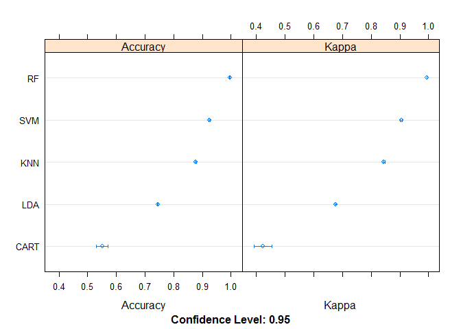

**Summary of various models accuracy and Kappa**

```
##
## Call:
## summary.resamples(object = results)
##
## Models: RF, CART, KNN, SVM, LDA
## Number of resamples: 25
##
## Accuracy
##        Min. 1st Qu. Median   Mean 3rd Qu.   Max. NA's
## RF   0.9932  0.9948 0.9952 0.9956  0.9963 0.9979    0
## CART 0.3729  0.5452 0.5664 0.5505  0.5781 0.6003    0
## KNN  0.8670  0.8740 0.8791 0.8774  0.8812 0.8862    0
## SVM  0.9148  0.9200 0.9239 0.9251  0.9298 0.9402    0
## LDA  0.7340  0.7408 0.7450 0.7444  0.7466 0.7561    0
##
## Kappa
##        Min. 1st Qu. Median   Mean 3rd Qu.   Max. NA's
## RF   0.9914  0.9934 0.9940 0.9945  0.9953 0.9974    0
## CART 0.1227  0.4118 0.4496 0.4232  0.4639 0.4910    0
## KNN  0.8321  0.8409 0.8468 0.8449  0.8496 0.8556    0
## SVM  0.8921  0.8987 0.9036 0.9051  0.9109 0.9241    0
## LDA  0.6628  0.6716 0.6775 0.6762  0.6792 0.6915    0
```

Let’s analyze the top two prediction in detail

**Random Forest Method**

```r
confusionMatrix(pred.rf, testing$classe)
```

```
## Confusion Matrix and Statistics
##
##           Reference
## Prediction    A    B    C    D    E
##          A 1860    6    0    0    0
##          B    0 1258    1    0    0
##          C    0    1 1139    5    0
##          D    0    0    0 1066    1
##          E    0    0    0    1 1201
##
## Overall Statistics
##
##                Accuracy : 0.9977
##                  95% CI : (0.9962, 0.9987)
##     No Information Rate : 0.2844
##     P-Value [Acc > NIR] : < 2.2e-16
##
##                   Kappa : 0.9971
##  Mcnemar's Test P-Value : NA
##
## Statistics by Class:
##
##                      Class: A Class: B Class: C Class: D Class: E
## Sensitivity            1.0000   0.9945   0.9991   0.9944   0.9992
## Specificity            0.9987   0.9998   0.9989   0.9998   0.9998
## Pos Pred Value         0.9968   0.9992   0.9948   0.9991   0.9992
## Neg Pred Value         1.0000   0.9987   0.9998   0.9989   0.9998
## Prevalence             0.2844   0.1935   0.1743   0.1639   0.1838
## Detection Rate         0.2844   0.1924   0.1742   0.1630   0.1837
## Detection Prevalence   0.2854   0.1925   0.1751   0.1632   0.1838
## Balanced Accuracy      0.9994   0.9971   0.9990   0.9971   0.9995
```

**Support Vector Machines Method**

```r
confusionMatrix(pred.svm, testing$classe)
```

```
## Confusion Matrix and Statistics
##
##           Reference
## Prediction    A    B    C    D    E
##          A 1828   97    1    6    1
##          B    8 1113   53    7   18
##          C   22   50 1061  122   34
##          D    1    1   25  937   32
##          E    1    4    0    0 1117
##
## Overall Statistics
##
##                Accuracy : 0.9261
##                  95% CI : (0.9195, 0.9324)
##     No Information Rate : 0.2844
##     P-Value [Acc > NIR] : < 2.2e-16
##
##                   Kappa : 0.9064
##  Mcnemar's Test P-Value : < 2.2e-16
##
## Statistics by Class:
##
##                      Class: A Class: B Class: C Class: D Class: E
## Sensitivity            0.9828   0.8798   0.9307   0.8741   0.9293
## Specificity            0.9776   0.9837   0.9578   0.9892   0.9991
## Pos Pred Value         0.9457   0.9283   0.8231   0.9408   0.9955
## Neg Pred Value         0.9931   0.9715   0.9850   0.9756   0.9843
## Prevalence             0.2844   0.1935   0.1743   0.1639   0.1838
## Detection Rate         0.2796   0.1702   0.1623   0.1433   0.1708
## Detection Prevalence   0.2956   0.1834   0.1971   0.1523   0.1716
## Balanced Accuracy      0.9802   0.9318   0.9442   0.9316   0.9642
```

## Final Prediction & Results

```r
predict(fit.rf, pmltesting)
```

```
##  [1] B A B A A E D B A A B C B A E E A B B B
## Levels: A B C D E
```